# neo4r

Lowson Li

# 1 Load packages

```r
library(tidyverse)
library(tidygraph)
library(igraph)
library(visNetwork)
library(spdep)
library(spatialreg)
library(igraph)
library(ade4)
```

# 2 Install latest version of neo4r

Dev version from GitHub

```r
remotes::install_github("neo4j-rstats/neo4r")
```

# 3 Connection

Create connection

```r
library(neo4r)
con <- neo4j_api$new(
  url = "http://b87c6e11.ap.ngrok.io",
  user = "neo4j",
  password = "neo4j"
  )
```

Check connection

```r
con$ping()
```

```
[1] 200
```

```r
con$get_version()
```

```
[1] "3.5.15"
```

```r
con$get_constraints()
```

[output not shown]

| property_keys | label | type |
| --- | --- | --- |
| id | Business | UNIQUENESS |
| id | Review | UNIQUENESS |
| id | User | UNIQUENESS |

```r
con$get_labels()
```

| labels |
| --- |
| Business |
| Review |
| Category |
| User |

```r
con$get_relationships()
```

| labels |
| --- |
| IN_CATEGORY |
| TIP |
| WROTE |
| REVIEWS |
| FRIEND |

```r
con$get_index()
```

[output not shown]

| property_keys | label | labels |
| --- | --- | --- |
| name | Category | Category |
| id | User | User |
| id | Review | Review |
| id | Business | Business |

# 4 Retrieve data from the API

Unnest node

```r
res <- 'MATCH (u:User)-[:WROTE]->(r:Review)-[:REVIEWS]->(b:Business)-[:IN_CATEGORY]->(c:Category)
    WHERE b.state = "AZ" AND b.is_open = 1 AND b.city ="Phoenix" AND c.id CONTAINS "Restaurant"
    WITH u MATCH (u)-[:FRIEND*0..1]-(n) WHERE n.name IS NOT NULL AND n.id <> "None"
    RETURN DISTINCT u  LIMIT 10' %>%
  call_neo4j(con, type = "graph")
unnest_nodes(res$nodes)
```

| id | value | compliment_more | compliment_writer | compliment_funny | average_stars | cool | review_count | compliment_plain | compliment_note | fans | elite | compliment_profile | yelping_since | compliment_hot | compliment_photos | name | compliment_cool | compliment_list | id1 | compliment_cute | useful | funny |
| --- | --- | --- | --- | --- | --- | --- | --- | --- | --- | --- | --- | --- | --- | --- | --- | --- | --- | --- | --- | --- | --- | --- |
| 691657 | User | 0 | 0 | 0 | 3.43 | 0 | 7 | 0 | 0 | 0 |  | 0 | 2014-06-29 18:34:10 | 0 | 0 | Denise | 0 | 0 | KN-TQSVCzMUUjjDZmBoMKw | 0 | 4 | 1 |
| 203675 | User | 2 | 2 | 2 | 2.66 | 108 | 162 | 6 | 19 | 16 |  | 0 | 2009-06-26 20:06:02 | 3 | 2 | Maryanne | 2 | 0 | t7b1lU39lHosuU9_U4jeuQ | 0 | 362 | 291 |
| 214816 | User | 1 | 0 | 2 | 3.72 | 35 | 54 | 6 | 3 | 10 |  | 0 | 2013-01-22 05:01:42 | 2 | 5 | Teresa Isamar | 2 | 0 | iCPiobbDTJSeo7sKcF_qQA | 0 | 87 | 33 |
| 591137 | User | 1 | 0 | 0 | 4.08 | 7 | 31 | 1 | 2 | 0 |  | 0 | 2014-07-07 01:39:42 | 0 | 0 | Mike | 0 | 0 | mCSfcQ9tgrDXuhdLtSwPhA | 0 | 34 | 8 |
| 8488367 | User | 0 | 0 | 0 | 5.00 | 0 | 1 | 0 | 0 | 0 |  | 0 | 2018-10-18 23:54:59 | 0 | 0 | Sam | 0 | 0 | 3rdnNWVlsrf_6nW2qc0_8A | 0 | 0 | 0 |
| 396808 | User | 0 | 0 | 0 | 5.00 | 4 | 5 | 0 | 1 | 0 |  | 0 | 2011-03-22 01:33:32 | 0 | 0 | Chris | 0 | 0 | mcwS6ite-X_AkATwwKEMYQ | 0 | 5 | 0 |
| 258921 | User | 0 | 0 | 0 | 3.83 | 0 | 17 | 0 | 0 | 0 |  | 0 | 2011-06-11 16:11:55 | 0 | 0 | Michele | 0 | 0 | mucxdPcuDEKd6oy5uAUiHA | 0 | 1 | 1 |
| 8464979 | User | 0 | 0 | 0 | 3.92 | 0 | 13 | 0 | 0 | 0 |  | 0 | 2014-10-24 07:44:15 | 0 | 0 | Shelly | 0 | 0 | Cokmpk6wcnbNVnvC1-ONVQ | 0 | 2 | 3 |
| 197712 | User | 9 | 92 | 71 | 4.13 | 1097 | 421 | 63 | 30 | 93 | 2013,2014,2015,2016,2017,2018 | 0 | 2008-07-25 15:20:49 | 30 | 31 | Brent | 71 | 0 | WMMI5Q4Rmm1Rqdu0jOvyhQ | 0 | 1789 | 601 |
| 354067 | User | 0 | 0 | 0 | 3.90 | 3 | 19 | 1 | 1 | 0 |  | 0 | 2011-01-29 20:26:24 | 0 | 0 | Ryan | 0 | 0 | rWadvy3l1aXeK8tHWizwRw | 0 | 18 | 2 |

Unnest graph

```r
res <- 'MATCH (u:User)-[:WROTE]->(r:Review)-[:REVIEWS]->(b:Business)-[:IN_CATEGORY]->(c:Category)
    WHERE b.state = "AZ" AND b.is_open = 1 AND b.city ="Phoenix" AND c.id CONTAINS "Restaurant"
    WITH u MATCH (u:User)-[f]-(n:User) WHERE u.name IS NOT NULL AND u.id <> "None" AND n.name IS NOT NULL AND n.id <> "None"
    RETURN DISTINCT u,Type(f),f,n limit 100' %>%
  call_neo4j(con, type = "graph") %>%
  unnest_graph()
```

```r
res$nodes
```

| id | value | compliment_more | compliment_writer | compliment_funny | average_stars | cool | review_count | compliment_plain | compliment_note | fans | elite | compliment_profile | yelping_since | compliment_hot | compliment_photos | name | compliment_cool | compliment_list | id1 | compliment_cute | useful | funny |
| --- | --- | --- | --- | --- | --- | --- | --- | --- | --- | --- | --- | --- | --- | --- | --- | --- | --- | --- | --- | --- | --- | --- |
| 203675 | User | 2 | 2 | 2 | 2.66 | 108 | 162 | 6 | 19 | 16 |  | 0 | 2009-06-26 20:06:02 | 3 | 2 | Maryanne | 2 | 0 | t7b1lU39lHosuU9_U4jeuQ | 0 | 362 | 291 |
| 258040 | User | 2 | 11 | 20 | 3.80 | 130 | 74 | 56 | 20 | 14 | 2012,2013 | 1 | 2010-03-01 08:42:30 | 2 | 0 | Lester | 20 | 0 | oBYbYmIPe2ny6W99aSMzlA | 0 | 259 | 118 |
| 1162247 | User | 0 | 0 | 0 | 4.50 | 0 | 4 | 0 | 0 | 0 |  | 0 | 2016-11-26 17:49:31 | 0 | 0 | Mariana | 0 | 0 | oR40wYNxuRoP1-S8I-Jmiw | 0 | 0 | 0 |
| 233023 | User | 1 | 0 | 1 | 3.73 | 13 | 43 | 1 | 2 | 0 |  | 0 | 2014-08-11 00:40:22 | 1 | 0 | Manny | 1 | 0 | OEGUw-3SJtzkhbH-ldO1xA | 0 | 25 | 7 |
| 877445 | User | 1 | 0 | 0 | 5.00 | 1 | 12 | 0 | 0 | 2 |  | 0 | 2015-10-02 00:52:00 | 0 | 0 | Nick | 0 | 0 | DniuRt8HM9hdPR-4SmpuJg | 0 | 2 | 1 |
| 263630 | User | 0 | 0 | 1 | 1.83 | 5 | 6 | 0 | 0 | 1 |  | 0 | 2012-07-15 01:58:34 | 0 | 0 | Michael | 1 | 0 | OJgtujP0KY434W9v5yxWAw | 0 | 30 | 6 |
| 205764 | User | 0 | 0 | 20 | 4.31 | 205 | 147 | 13 | 7 | 13 |  | 0 | 2011-05-25 19:39:45 | 8 | 5 | Jro | 20 | 0 | hDiuDhttkIEt8_wVwufDvg | 0 | 260 | 142 |
| 200653 | User | 1 | 3 | 34 | 3.95 | 299 | 423 | 19 | 14 | 13 | 2017,2018 | 1 | 2012-10-07 20:30:05 | 12 | 3 | Ron | 34 | 0 | PdgpUK6fHArEXsPcKFHXOg | 0 | 503 | 106 |
| 195741 | User | 0 | 0 | 2 | 4.74 | 13 | 31 | 1 | 1 | 1 |  | 0 | 2012-07-24 01:42:33 | 1 | 0 | Tony | 2 | 0 | QTq-x355EVmjMq4gpUOd-A | 0 | 30 | 5 |
| 195700 | User | 0 | 3 | 6 | 3.67 | 4 | 12 | 20 | 8 | 8 |  | 0 | 2010-01-26 00:53:28 | 2 | 0 | Errol | 6 | 0 | SbSuQYWCJTZkRXrmxrMzcg | 0 | 14 | 0 |

[output cut: 94 more lines]

```r
res$relationships
```

| id | type | startNode | endNode | value |
| --- | --- | --- | --- | --- |
| 24991243 | FRIEND | 203675 | 258040 | NA |
| 24991247 | FRIEND | 203675 | 1162247 | NA |
| 24991242 | FRIEND | 203675 | 233023 | NA |
| 24991239 | FRIEND | 203675 | 877445 | NA |
| 24991244 | FRIEND | 203675 | 263630 | NA |
| 23052592 | FRIEND | 205764 | 203675 | NA |
| 21169097 | FRIEND | 200653 | 203675 | NA |
| 21157327 | FRIEND | 195741 | 203675 | NA |
| 21035169 | FRIEND | 195700 | 203675 | NA |
| 24204550 | FRIEND | 214816 | 1458557 | NA |

[output cut: 90 more lines]

Extract with `path`

```r
res <- 'MATCH (u:User)-[:WROTE]->(r:Review)-[:REVIEWS]->(b:Business)-[:IN_CATEGORY]->(c:Category)
WHERE b.state = "AZ" AND b.is_open = 1 AND b.city ="Phoenix" AND c.id CONTAINS "Restaurant"
WITH u
MATCH p=(u:User)-[f]-(n:User)
WHERE u.name IS NOT NULL AND u.id <> "None" AND n.name IS NOT NULL AND n.id <> "None"
RETURN DISTINCT p LIMIT 100' %>%
  call_neo4j(con, type = "graph") %>%
  unnest_graph()
```

# 5 Convert to igraph

Prepare nodes

```r
res$nodes <-
  res$nodes %>%
  select(id, label = value, everything())
```

Prepare relationships

```r
res$relationships <- res$relationships %>%
  select(startNode, endNode, type, everything())
```

Save network in igraph

```r
graph_object <- igraph::graph_from_data_frame(
  d = res$relationships,
  directed = FALSE,
  vertices = res$nodes
)
```

# 6 Strategy

Since the path is too large for directed import to `igraph` object via `neo4r`, I decide to export: 1) node list 2) relationship list

from `neo4j` directly.

After getting these 2 critical information, I can create `igraph` object.

## 6.1 Export nodes & relationships from neo4j

Cypher - export users nodes

```
WITH "MATCH (u:User)-[:WROTE]->(:Review)-[:REVIEWS]->(b:Business)-[:IN_CATEGORY]->(c:Category)
WHERE b.is_open =1 AND b.state = 'AZ' AND c.id CONTAINS 'Restaurant' AND b.city = 'Phoenix' AND b.is_open = 1
WITH u
MATCH (u)-[:FRIEND*0..1]-(f)
WHERE u.name IS NOT NULL AND u.id <> 'None' AND f.name IS NOT NULL AND f.id <>'None'
WITH DISTINCT f
RETURN id(f) as neo_id, f.id as user_id" AS query
CALL apoc.export.csv.query(query, "node.csv", {})
YIELD file, source, format, nodes, relationships, properties, time, rows, batchSize, batches, done, data
RETURN file, source, format, nodes, relationships, properties, time, rows, batchSize, batches, done, data;
```

Cypher - export relationships

```
WITH "MATCH (u:User)-[:WROTE]->(:Review)-[:REVIEWS]->(b:Business)-[:IN_CATEGORY]->(c:Category)
WHERE b.is_open =1 AND b.state = 'AZ' AND c.id CONTAINS 'Restaurant' AND b.city = 'Phoenix' AND b.is_open = 1
WITH u
MATCH p=(u)-[:FRIEND]-(f)
WHERE u.name IS NOT NULL AND u.id <> 'None' AND f.name IS NOT NULL AND f.id <>'None'
WITH DISTINCT p
UNWIND apoc.coll.pairsMin(nodes(p)) as pair
RETURN id(pair[0]) as from, id(pair[1]) as to" AS query
CALL apoc.export.csv.query(query, "friendship2.csv", {})
YIELD file, source, format, nodes, relationships, properties, time, rows, batchSize, batches, done, data
RETURN file, source, format, nodes, relationships, properties, time, rows, batchSize, batches, done, data;
```

## 6.2 Node check

Import nodes

```r
library(readr)
node <- read_csv("~/neo4j-community-3.5.15/import/node.csv")
```

Check for distinct node

```r
node %>%
  distinct(neo_id) %>%
  nrow()
```

```
[1] 436905
```

## 6.3 Relationship check

Load the distinct path version of relationship

```r
library(readr)
friendship2 <- read_csv("~/neo4j-community-3.5.15/import/friendship2.csv")
```

Count all path

```r
friendship2 %>%
  nrow()
```

```
[1] 2352204
```

Count distinct start node

```r
friendship2 %>%
  distinct(from) %>%
  nrow()
```

```
[1] 82810
```

Count distinct end node

```r
friendship2 %>%
  distinct(to) %>%
  nrow()
```

```
[1] 358697
```

Count distinct path

```r
friendship2 %>%
  distinct(from, to) %>%
  nrow()
```

```
[1] 2352204
```

## 6.4 Test igraph object

```r
graph_object <- igraph::graph_from_data_frame(
  d = friendship2,
  directed = FALSE,
  vertices = node
)
```

# 7 Network and node descriptives

## 7.1 Density

The proportion of present edges from all possible edges in the network.

```r
edge_density(graph_object, loops=F)
```

```
[1] 2.464518e-05
```

## 7.2 Transitivity

- global - ratio of triangles (direction disregarded) to connected triples.
- local - ratio of triangles to connected triples each vertex is part of.

```r
transitivity(graph_object, type="global")  # net is treated as an undirected network
```

```
[1] 0.03150029
```

## 7.3 Diameter

A network diameter is the longest geodesic distance (length of the shortest path between two nodes) in the network. In `igraph`, `diameter()` returns the distance, while `get_diameter()` returns the nodes along the first found path of that distance.

Note that edge weights are used by default, unless set to NA.

```r
diameter(net, directed=F, weights=NA)
```

[output not shown]

## 7.4 Degrees

The function `degree()` has a mode of `in` for in-degree, `out` for out-degree, and `all` or total for total degree.

Degree distribution

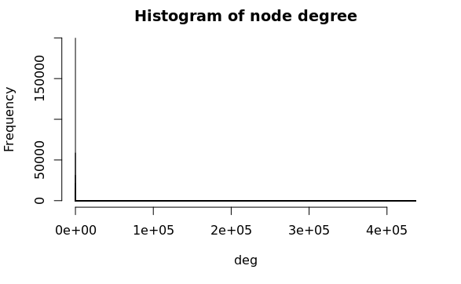

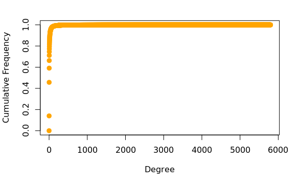

# 8 Community detection

## 8.1 Newman-Girvan

Community detection based on edge betweenness. High-betweenness edges are removed sequentially (recalculating at each step) and the best partitioning of the network is selected.

```r
 # ceb <- cluster_edge_betweenness(grgraph_object)
# slow, do not run
```

Community detection based on greedy optimization of modularity

```r
cfg <- cluster_fast_greedy(graph_object)
```

```
Error in cluster_fast_greedy(graph_object) :
  At fast_community.c:639 : fast-greedy community finding works only on graphs without multiple edges, Invalid value
```

```r
cfg <-
  simplify(graph_object) %>%
  cluster_fast_greedy()
```

# 9 Reference

[Using R & Neo4J](https://neo4j-rstats.github.io/user-guide/) [Network and node descriptives](https://kateto.net/netscix2016.html)